# Formulas (solutions)

## Primary exercises

1. *A formula in a function; simple linear regression*.  
   Load the `survey.csv` data to variable `survey`.  
   You may make a simple scatter plot with `plot( survey$span2, survey$span1 )`.  
   Perform a linear regression of `span1` being dependent on `span2`; store the result in `fit` variable.  
   `fit` behaves also like a `list` so show `names` of elements stored in `fit`.  
   Find and print the element corresponding to the coefficients of the regression – do you see there a coefficient for `span2`?  
   An intended method to access the coefficients is through `coef` function applied to `fit`. Try it. Do you get the same result as observed above?

```r
survey <- read_csv( "survey.csv" )
```

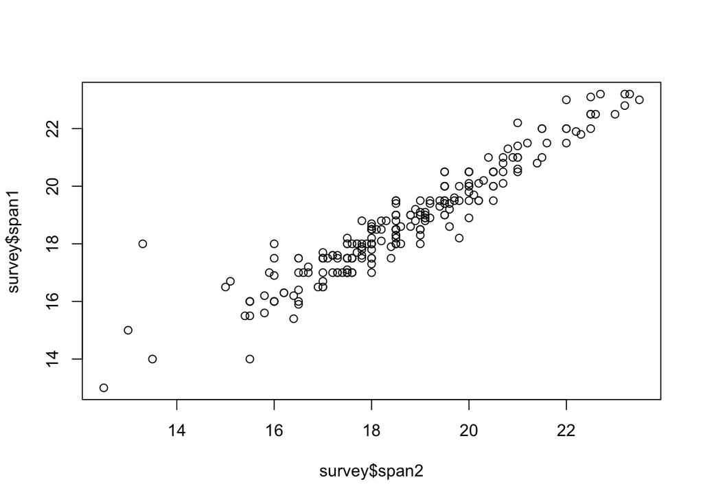

```r
plot( survey$span2, survey$span1 )
```

```r
fit <- lm( span1 ~ span2, data = survey )
fit
```

```
Call:
lm(formula = span1 ~ span2, data = survey)

Coefficients:
(Intercept)        span2
     1.9367       0.9001
```

```r
names( fit )
```

```
 [1] "coefficients"  "residuals"     "effects"       "rank"          "fitted.values" "assign"        "qr"
 [8] "df.residual"   "xlevels"       "call"          "terms"         "model"
```

```r
fit$coefficients
```

```
(Intercept)       span2
  1.9367408   0.9000552
```

```r
coef( fit )
```

```
(Intercept)       span2
  1.9367408   0.9000552
```

## Extra exercises

1. *Simple regression diagnostic plots (demo)*.  
   Apply `plot` function to the `fit` object calculated in the above exercise.  
   These are diagnostic plots for the model produced by `lm`.

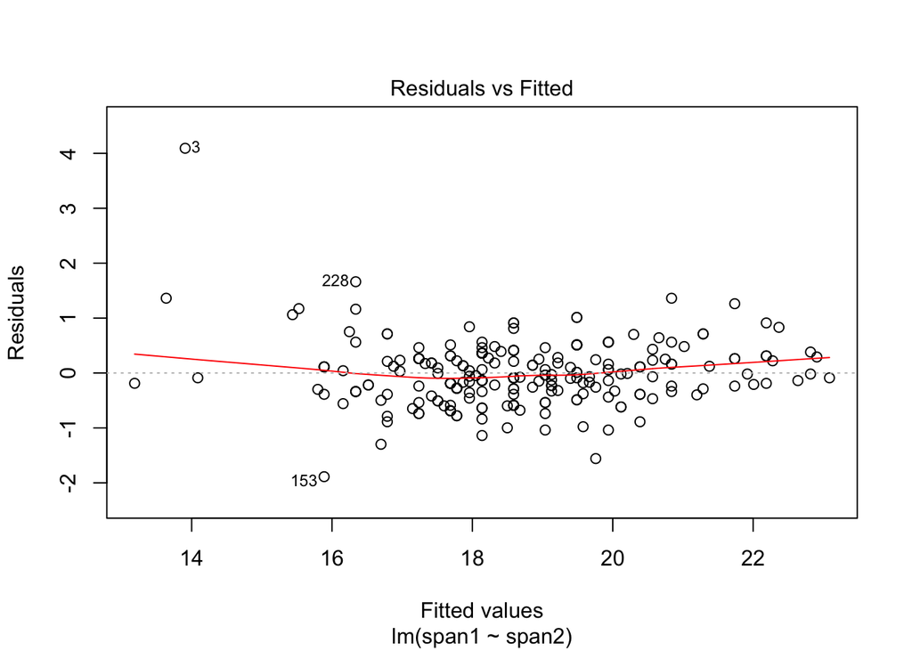

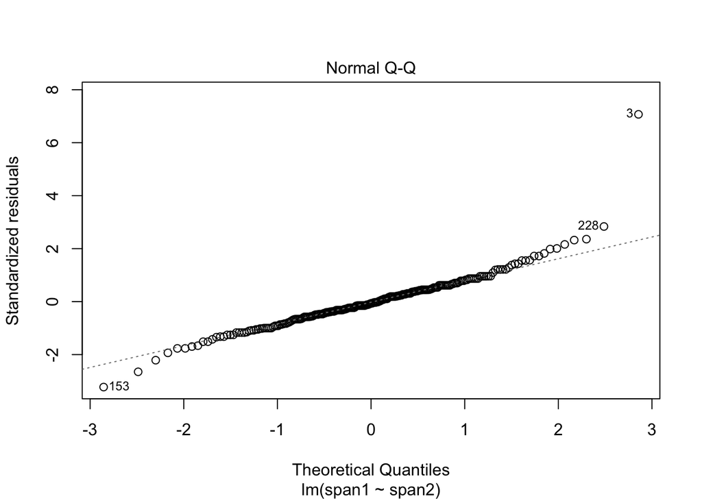

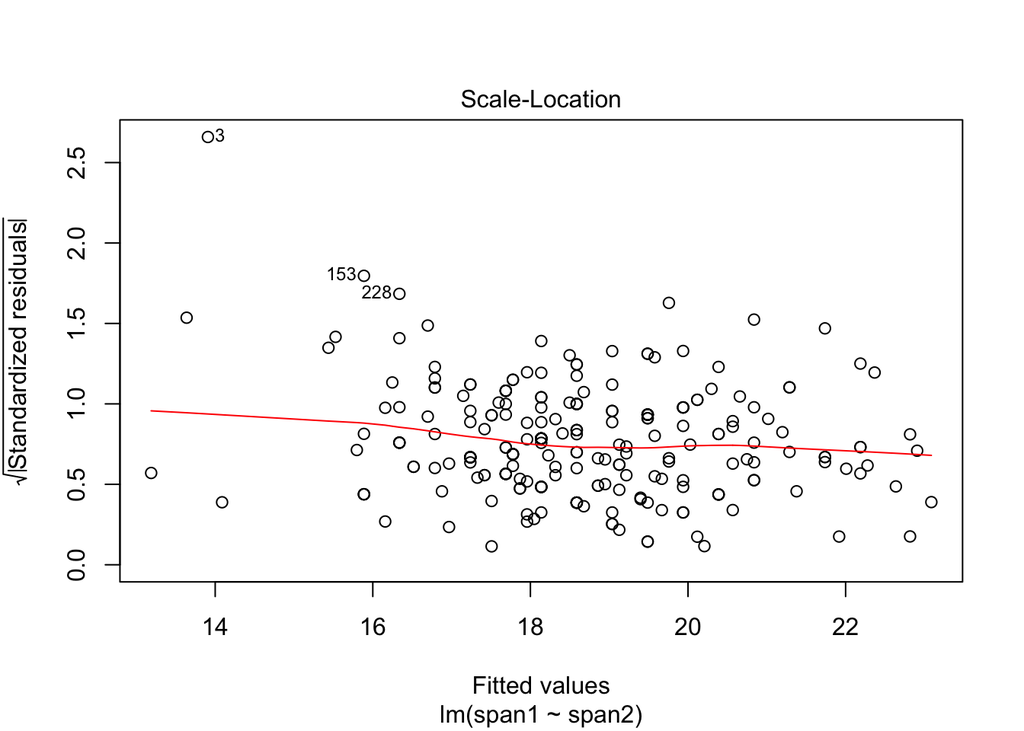

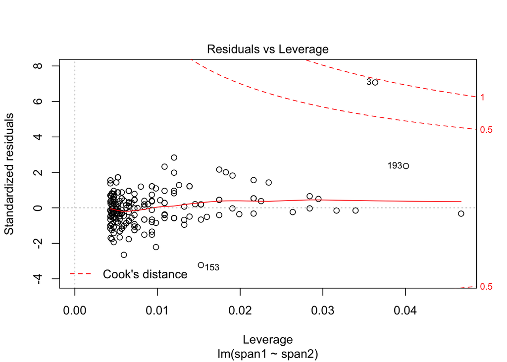

```r
plot( fit )
```

2. *Another test for association/correlation*.  
   In one of the extra list exercises a test for correlation between two random vectors was performed.  
   Follow the same steps to test correlation between `span1` and `span2` of `survey`.  
   Is correlation between these vectors significant?

```r
h <- cor.test( survey$span2, survey$span1 ) # vector notation
h <- cor.test( formula = ~ span2 + span1, data = survey )  # formula notation
h
```

```
    Pearson's product-moment correlation

data:  span2 and span1
t = 45.203, df = 231, p-value < 2.2e-16
alternative hypothesis: true correlation is not equal to 0
95 percent confidence interval:
 0.9329904 0.9594917
sample estimates:
      cor
0.9478552
```

```r
names( h )
```

```
[1] "statistic"   "parameter"   "p.value"     "estimate"    "null.value"  "alternative" "method"      "data.name"
[9] "conf.int"
```

```r
h[[ 'estimate' ]]   # correlation coefficient
```

```
      cor
0.9478552
```

```r
h[[ 'p.value' ]]    # significance, is < 0.05, strongly significant association
```

```
[1] 1.057707e-116
```

## Multitopic exercises

### (ADV) Fitting multiple simple linear regressions to parts of a table.

Load the `pulse.csv` dataset into the `pulse` variable.  
Let’s define the following goal: **separately for each `gender`** calculate a linear fit of `weight` as a function of `height`.

First `split` the `pulse` table by `gender` into the `pulseByGender` variable.

```r
pulseByGender <- pulse %>% split( .$gender )
```

Now, `pulseByGender` is a list and can be accessed with `[[...]]` operator.  
Write the code to perform a linear fit of `weight` as a function of `height` **for females only** (obtained from `pulseByGender` list).

```r
lm( weight ~ height, data = pulseByGender[[ "female" ]] )
```

```
Call:
lm(formula = weight ~ height, data = pulseByGender[["female"]])

Coefficients:
(Intercept)       height
    -22.691        0.482
```

The next goal is to perform the above fit multiple times, separately for each gender.  
Define a variable `genders` with all genders present in the split object.

```r
genders <- names( pulseByGender )
genders
```

```
[1] "female" "male"
```

Now a loop is needed.  
A variable `gender` should iterate over all `genders`.  
For each value of `gender` the respective linear fit should be performed.  
Understand and try the following code:

```r
for( gender in genders ) {
  lm( weight ~ height, data = pulseByGender[[ gender ]] )
}
```

The above code calculates all needed fits but does show/store the results anywhere.  
The results need to be stored, for example in a list.  
Understand/modify the code as follows:

```r
fitByGender <- list()
for( gender in genders ) {
  fitByGender[[gender]] <- lm( weight ~ height, data = pulseByGender[[ gender ]] )
}
fitByGender
```

```
$female

Call:
lm(formula = weight ~ height, data = pulseByGender[[gender]])

Coefficients:
(Intercept)       height
    -22.691        0.482


$male

Call:
lm(formula = weight ~ height, data = pulseByGender[[gender]])

Coefficients:
(Intercept)       height
    17.3348       0.3231
```

```r
fitByGender[[ "female" ]]
```

```
Call:
lm(formula = weight ~ height, data = pulseByGender[[gender]])

Coefficients:
(Intercept)       height
    -22.691        0.482
```

A special function `lapply` allows to write the above code differently.  
In R this is a preferred notation (despite being less intuitive at the first glance).  
Rewrite the `for` loop into `lapply` as follows:

```r
fitByGender <- lapply( genders, function( gender ) {
  lm( weight ~ height, data = pulseByGender[[ gender ]] )
} )
fitByGender
```

```
[[1]]

Call:
lm(formula = weight ~ height, data = pulseByGender[[gender]])

Coefficients:
(Intercept)       height
    -22.691        0.482


[[2]]

Call:
lm(formula = weight ~ height, data = pulseByGender[[gender]])

Coefficients:
(Intercept)       height
    17.3348       0.3231
```

```r
names( fitByGender )
```

As you can see, `fitByGender` is a list but the elements are not named.  
This is because `lapply` names the elements as they were named in the iterated input.  
Check `names` of `genders` (you will see `NULL` names).

```r
genders
```

```
[1] "female" "male"
```

```r
names( genders )
```

Consequently, set the names of `genders` elements to be equal to the element values.

```r
names( genders ) <- genders
genders
```

```
  female     male
"female"   "male"
```

Now, let’s repeat the `lapply` loop and check the result.  
Check (by eye) that `fitByGender[[ 'female' ]]` shows the same result as at the top of this example.

```r
fitByGender <- lapply( genders, function( gender ) {
  lm( weight ~ height, data = pulseByGender[[ gender ]] )
} )
fitByGender
```

```
$female

Call:
lm(formula = weight ~ height, data = pulseByGender[[gender]])

Coefficients:
(Intercept)       height
    -22.691        0.482


$male

Call:
lm(formula = weight ~ height, data = pulseByGender[[gender]])

Coefficients:
(Intercept)       height
    17.3348       0.3231
```

```r
fitByGender[[ 'female' ]] # compare to lm( weight ~ height, data = pulseByGender[[ "female" ]] )
```

```
Call:
lm(formula = weight ~ height, data = pulseByGender[[gender]])

Coefficients:
(Intercept)       height
    -22.691        0.482
```